# Model details

Graeme Baird

5/24/2018

### Underlying model details

In this paper we present an extension of a cumulative link ordinal regression model to include nonlinear effects, briefly described below.

The highest level of the model is a multinomial distribution mapping the ordinal bud-state outcomes [dormant 0; greentip 1; leaf-out 2] to categorical probabilities. For convenience we follow the model formulation by McKinley CITE, rephrased for this dataset, though other formulations of the cumulative link model have been well-described in frequentist and Bayesian contexts elsewhere. Set $Y_{ij}$ in ($Y_{i1}, Y_{i2}, Y_{i3}$) to be the ordinal group j for any observation i, $n_i$ the individual observed bud, and $\textbf{p}_i$ to be the vector of probabilities of occupying group j, yielding the unordered multinomial distribution

$Y \sim Mult(n_i,\textbf{p}_i)$

where $\textbf{p}_i$ = ($p_{i1}, p_{i2}, p_{i3}$). Coercing this distribution to an ordered form can be accomplished by linking the cumulative probability for each outcome $i$ occupying any group $j$ to a continuous variable $\gamma_{ij}$ via the monotonic increasing link function

$h(\gamma_{ij}) = \theta_j - \mu_i$

where $\theta_j$ is a set of cut-points (in this dataset, 2 cut-points) and $\mu_i$ is a regression term. In this case $\gamma$ serves as a convenient representation of the continuous underlying biological development process as each bud moves through the observed phenological stages. A link to chill and heat accumulation is assumed via

$\mu_i = GDH_i * f(CP,\theta)$

where $GDH_i$ is the accumulated growing degree hours at observation $i$ and $f(CP,\theta)$ is any nonlinear function on chilling portions and parameters $\theta$. In this case we use the standard logistic function

$f(CP,\theta) = f(CP, \alpha, \beta, \eta) = \alpha * (1 + exp(\beta - \eta*CP))^{-1}$

where $\alpha$ is the asymptote, $\beta$ is the location, and $\eta$ is the scale parameter.

Conveniently, the derivatives of the logistic equation are well-studied, and have key properties useful to us - the first differential maxima indicate the transition between periods in the high-responsivity period, second differential minima indicate the transition to a “saturation period” of growth.

$f^{(4)}(CP,\theta)$ has three roots, and the third root is at the final saturation inflection of the sigmoid curve, with a closed-form analytical solution of the form

which, in the Stan code, can be determined simultaneously in the ``generated quantities" block via

`Ysat = -log(5 - 2*sqrt(6)) + mu_beta)/mu_eta`

### Plotting response of nonlinear CP equation to changes in parameters (X:CP, Y:Coefficient output)

Parameter variance within the non-linear component is best visualized by piecemeal manipulation of individual parameters, as follows. Parameter ranges demonstrated below are appropriate for un-scaled variables and don’t necessarily match actual model parameter estimates, which are fit on scaled observations.

#### Changes in alpha determine asymptotic maximum possible growth rate

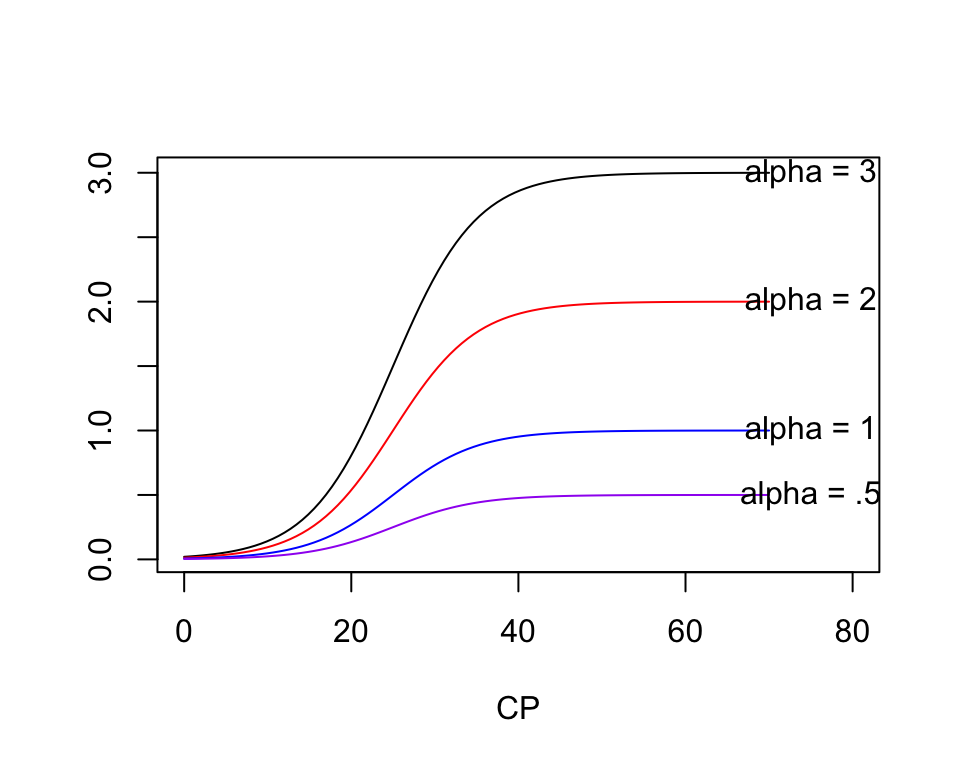

#### Changes in beta determine acceleration between inflection points

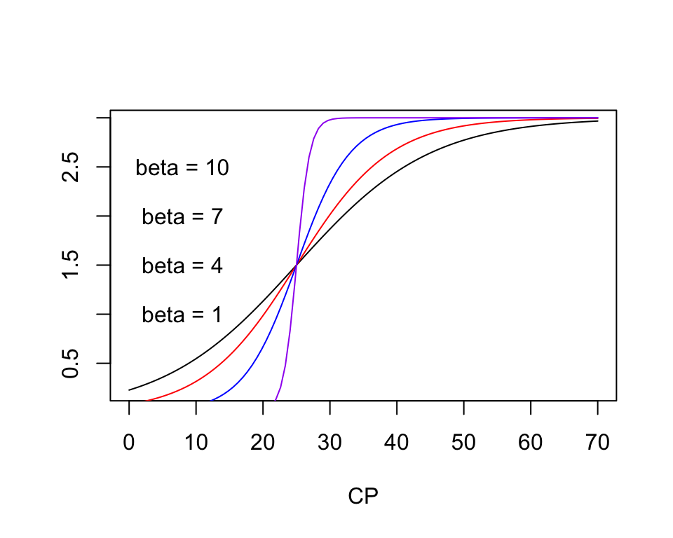

#### Changes in eta determine overall location of curve

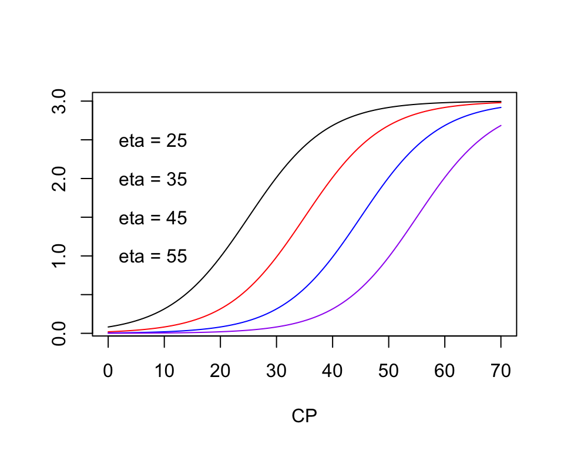

#### Gamma responsivity to GDH given fixed parameters and varying CP rates

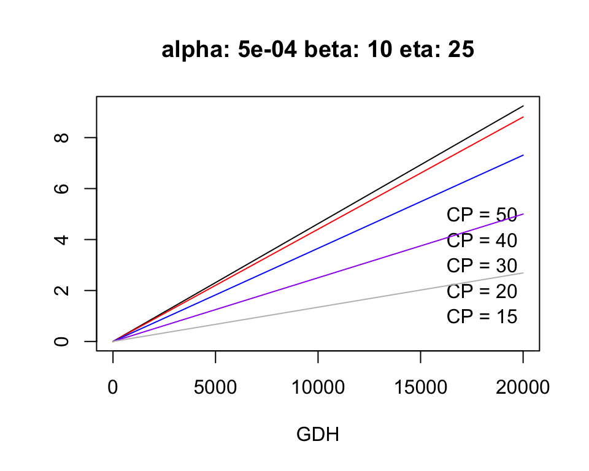

#### Simulated budbreak responsivity (proportion in [0,1]) to GDH given fixed parameters, varying CP rates, and arbitrary cutpoints (2,5)

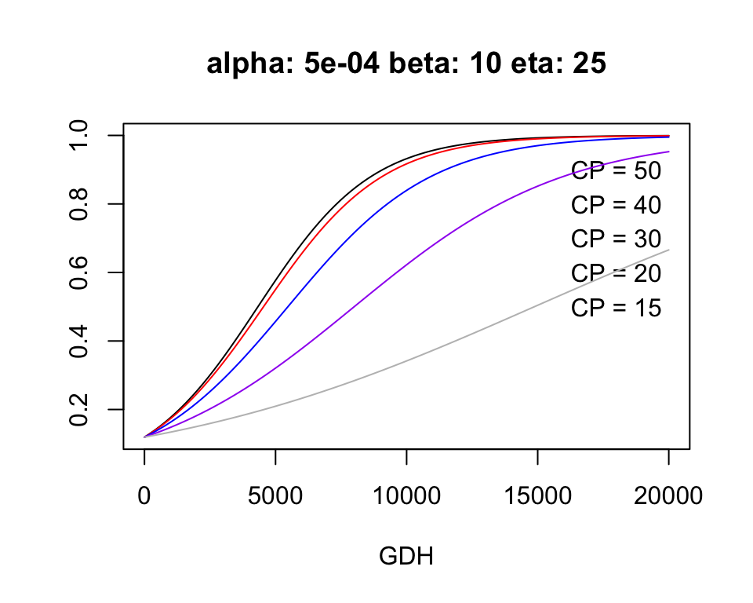